# Time series analysis of financial data

S M Safiul Alom

January 28, 2019

### Install Packages and load dataset

```r
#remove all grafics and objects
rm(list = ls())
#function for installing required packages
install.load.packages = function(pack, packagePath){
  all.packages = pack[!(pack %in% installed.packages(lib.loc = packagePath)[, 1])]
  if (length(all.packages))
    install.packages(all.packages, lib = packagePath, dependencies = TRUE)
  sapply(pack, require, lib.loc = packagePath, character.only = TRUE)
}
libraryPath = "C:\\Users\\Himel\\OneDrive\\Studium\\R\\Packages"
packages =  c("zoo", "ggplot2", "dplyr", "tidyr", "data.table", 'corrplot',
              'gridExtra', 'forecast', 'tseries', 'aTSA', 'tibble', 'TTR',
              "quantmod")
#install and load packages
install.load.packages(packages, libraryPath)
```

```
       zoo    ggplot2      dplyr      tidyr data.table   corrplot  gridExtra
      TRUE       TRUE       TRUE       TRUE       TRUE       TRUE       TRUE
  forecast    tseries       aTSA     tibble        TTR   quantmod
      TRUE       TRUE       TRUE       TRUE       TRUE       TRUE
```

```r
#get data
SP500 = new.env()
quantmod::getSymbols.csv("SP500afterClean",env = SP500,
                         dir = "C:\\Users\\Himel\\OneDrive\\Studium\\M.Sc. Statistics\\1_Statistical Programming Language\\Lecture_Exercise\\Data")
```

```
[1] "SP500AFTERCLEAN"
```

```r
SP500Series = SP500$SP500AFTERCLEAN
colnames(SP500Series) = gsub("SP500AFTERCLEAN.", "",colnames(SP500Series))
SP500_PRICE = quantmod::Cl(SP500Series)
#head(SP500_PRICE)
Daily_Return = quantmod::dailyReturn(SP500_PRICE, subset=NULL, type='log')
#timeseries for SP500-Price
```

### Time Series Plot: S&P 500

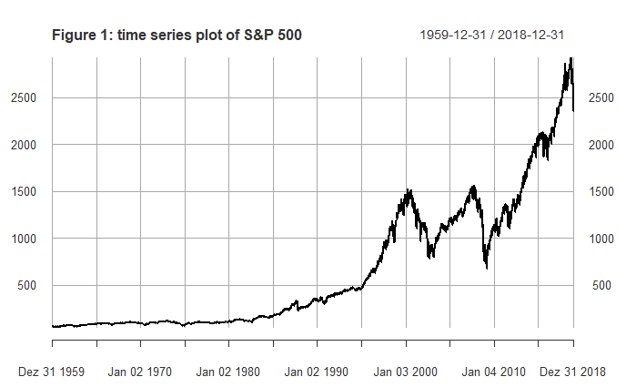

```r
plot(SP500_PRICE, main = "Figure 1: time series plot of S&P 500")
```

### Stationarity

- A process is called **(weak)stationary** if
  - the mean of $y_{t}$ is constant, i.e.

  $$\mathbb{E}(y_{t}) = \mu \qquad \forall t \in \left\{ 1,\ldots,T \right\}$$
  - the variance of $y_{t}$ is constant, i.e.

  $$\mathbb{V}(y_{t}) = \sigma^{2} \qquad \forall t \in \left\{ 1,\ldots,T \right\}$$
  - the covariance between $y_{t}$ and $y_{t+h}$ only depends on h:

  $$Cov(y_{t},y_{t+h}) = C(h)$$
- A process is called **(strickly)stationary** if the destribution of $(y_{t+h})_{t = 1,...,T}$ doesn’t depends on h, i.e.

$$\mathbb{P}( y_{t_1},\ldots,y_{t_n}) \stackrel{d }{=} \mathbb{P}( y_{t_1+h},\ldots,y_{t_n+h}) \qquad \forall \left\{t_{1},\ldots, t_{n}\right\} \subset \mathbb{T} = \left\{1,\ldots, T\right\}, h\in \mathbb{Z}\; and \; n>0$$

### Stock-return Plot: S&P 500

**Log-return:** $r_{t} = log(y_{t}) - log(y_{t-1})$

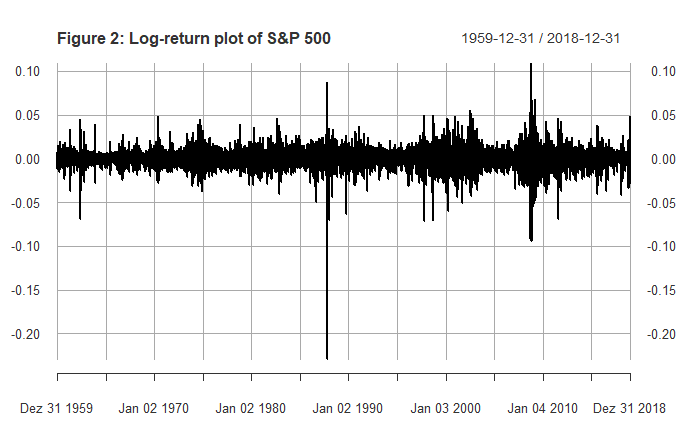

```r
plot(Daily_Return, main = "Figure 2: Log-return plot of S&P 500")
```

### ADF-Test

Above time series of log-return looks stationary.  
To confirm the stationarity we will use ADF-test(Augmented Dickey-Fuller test)

```r
# par(mfrow = c(1,2))
# a = ggplot2::autoplot(stats::acf(Daily_Return, lag.max = 50, type = "correlation", plot = FALSE)) + ggtitle("ACF(Log-return)")
#  b = ggplot2::autoplot(stats::acf(Daily_Return, lag.max = 50, type = "partial", main = "", plot = FALSE))  + ggtitle("PACF(Log-return)")
# grid.arrange(a, b, nrow = 1)
#Test of stationarity: dicky-fuller test
#tseries::adf.test(SP500_PRICE, alternative = "stationary", k = 0)
tseries::adf.test(Daily_Return, alternative = "stationary", k = 0)
```

```
p-value smaller than printed p-value
```

```
    Augmented Dickey-Fuller Test

data:  Daily_Return
Dickey-Fuller = -119.36, Lag order = 0, p-value = 0.01
alternative hypothesis: stationary
```

Since p-value < 0.01 we can reject $H_{0}$: non-stationarity with a confidence level of 0.99

In **Figure 1** is already shown that the time series of S&P is non-stationary. therefore a transformation of the data is needed for getting a stationary time series. An Example of the transformation of time series we have seen in **Figure 2** . One of the most popular modelclass to work with non-stationary time series data is **ARIMA** fitting.ARIMA models are aslo very popular in financial time series analysis because financial time series data are often non stationary.Therefore we will use ARIMA models to analysis our data.

### ARIMA models

The **ARIMA($p,d,q$)** is given by (for d = 0):

$$\Delta^0 y_{t} = a_{1}\Delta^0 y_{t-1} + a_{2}\Delta^0 y_{t-2} + \ldots + a_{p}y_{t-p} + \epsilon_{t} + b_{1}\epsilon_{t-1} + \ldots + b_{q}\epsilon_{t-q} \Leftrightarrow\\
y_{t} = a_{1}y_{t-1} + a_{2}y_{t-2} + \ldots + a_{p}y_{t-p} + \epsilon_{t} + b_{1}\epsilon_{t-1} + \ldots + b_{q}\epsilon_{t-q} \\$$

$\epsilon_{t}\sim N(0,\sigma^2) \; iid$  
p := lag order of the autoregressive(AR) model  
q := lag order of the; moving average(MA) model  
d := degree of differencing

here we take $d$ = 0, since our original time series is already transformed to log-return by differencing and log-transformation. $d$ can also take a higher value, if necessary. Now we come to the question, how can be found an appropriate model fit **ARIMA($p,d,q$)**. In practice following steps are taken to identify the approperiate hyperperameter p and q to select the approperiate model fit:

- finding approperiate p and q by graphical illustration of ACF(Autocorrelation) and PACF(Partial autocorrelation)
- Selection creteria(AIC and BIC) to overcome the problem of overparameterization
- Diagnostic checking of model with identified hyperparameter

### ACF and PACF

**Autocorrelation:** The correlation coeficient between $y_{t}$ and $y_{t-1}$ is denoted by $\rho_{k}$. $\rho_{k}$ is called k-lags autocorrelation and defined by:

$$\rho_{k} = \frac{Cov(y_{t},y_{t-k})}{\sqrt{Var_{t}}\sqrt{Var_{t-k}}} \in [-1,1]$$
$\rho_{k}$ is also called normalized autocovariance of $y_{t}$ and $y_{t-k}$, which lies between -1 and 1.

**Partial autocorrelation:** Partial autocorrelation of $y_{t}$ and $y_{t-k}$ is Correlation between $y_{t}$ and $y_{t-k}$ without any influence of $y_{t-1} \ldots y_{t-k+1}$

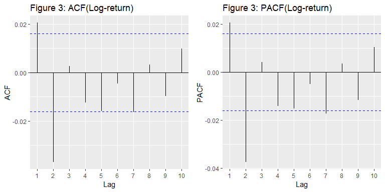

```r
par(mfrow = c(1,2))
a = ggplot2::autoplot(stats::acf(Daily_Return, lag.max = 10, type = "correlation", plot = FALSE)) + ggtitle("Figure 3: ACF(Log-return)")
b = ggplot2::autoplot(stats::acf(Daily_Return, lag.max = 10, type = "partial", main = "", plot = FALSE))  + ggtitle("Figure 3: PACF(Log-return)")
grid.arrange(a, b, nrow = 1)
```

The ACF and PACF in Figure 3 indicates that there is a strong correlation in lags 1 and 2, partial correlation in lags 1,2 and 7. Therefore log-return of S&P 500 can de modeled by **ARIMA** fit, for example by **ARIMA($1,0,1$)**

### Selection criteria

In practice, it is often complicated to in identify the appropriate hyperparameters from ACF and PACF plot. Because subjectivity plays a big role in this approach. consequently the model are sometimes overparameterized. to overcome this problem several selection criteria are often used in practice. We consider here two widely used selection criteria for model identification, namely Akaike Information Criterion (AIC) and Bayesian or Schwartz Information Criteria (BIC). AIC and BIC are defined by:

$$AIC(M) = 2logL(M) + 2p(M)\\
BIC(M) = -2logL(M) + p(M)logn$$

$n$: number of observation  
$p(M)$: number of parameter in model M  
$L(M)$: Likelihood function of Parameter evaluated at maximum lakelihood Estimator

In the approach of selection creteria following steps are taken:

### Table of AIC and BIC

```r
library(knitr)
library(kableExtra)
#grid search
fit = list()
p = c(0,1,2,3,4,5)
d = c(0)
q = p
order = expand.grid(p,d,q)
colnames(order) = c("p", "d", "q")
order$AIC = NA
order$BIC = NA
for(i in 1:nrow(order)){
  fit[[i]] = forecast::Arima(Daily_Return, order = as.integer(order[i,c(1,2,3)]))
  order$AIC[i] = fit[[i]]$aic
  order$BIC[i] = fit[[i]]$bic
}
#table of AIC and BIC for all possible combination of p and q
kable(order[1:5,]) %>%
  kable_styling("striped", full_width = T)
```

| p | d | q | AIC | BIC |
| --- | --- | --- | --- | --- |
| 0 | 0 | 0 | -94592.60 | -94577.39 |
| 1 | 0 | 0 | -94596.90 | -94574.08 |
| 2 | 0 | 0 | -94615.72 | -94585.30 |
| 3 | 0 | 0 | -94613.99 | -94575.96 |
| 4 | 0 | 0 | -94614.94 | -94569.30 |

### Hyperparameter of best model

```r
min.AIC_BIC = order[sapply(order[, c(4,5)], which.min),]
rownames(min.AIC_BIC) = NULL
kable(min.AIC_BIC, row.names = NA) %>%
  kable_styling("striped", full_width = T) %>% row_spec(as.numeric(c(1:nrow(min.AIC_BIC))), bold = T, color = "white", background = "#D7261E")
```

| p | d | q | AIC | BIC |
| --- | --- | --- | --- | --- |
| 5 | 0 | 4 | -94636.01 | -94552.34 |
| 0 | 0 | 2 | -94616.43 | -94586.01 |

### Best ARIMA-model

```r
best.Fit = stats::arima(Daily_Return, order = c(0,0,2))
coef.arima = round(coef(best.Fit), digits = 4)
coef.arima
```

```
      ma1       ma2 intercept
   0.0216   -0.0381    0.0003
```

### Diagonistic checking

The main objective is to check the model assumption. i.e.

- is error $\epsilon_{t}$ normally distributed?
- is error $\epsilon_{t}$ a WN(White Noise) process? i.e.
  - $E(\epsilon_{t}) = 0$
  - $Var(\epsilon_{t}) = \sigma^2$ $\quad \forall t$ and
  - $Cov(\epsilon_{t}, \epsilon_{t-k}) = 0$ $\quad \forall k>0$

```
    Ljung-Box test

data:  Residuals from ARIMA(0,0,2) with non-zero mean
Q* = 15.233, df = 7, p-value = 0.03312

Model df: 3.   Total lags used: 10
```

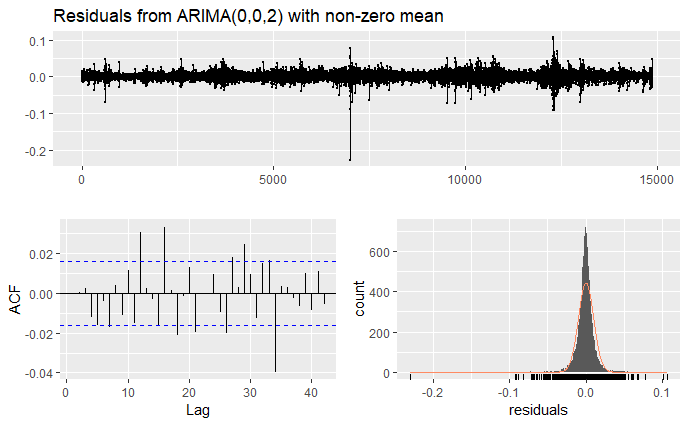

```r
checkresiduals(best.Fit)
```

- the time series plot shows that the mean of $\epsilon_{t}$ is very close to zero. But Variance of $\epsilon_{t}$ is not constant over time.

```r
mean(best.Fit$residuals)
```

```
[1] -9.847371e-09
```

### Q-Q Plot of $\epsilon_{t}$

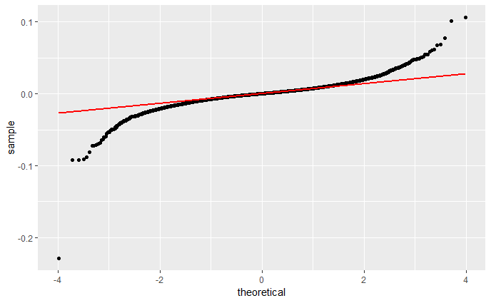

```r
resid.arima = data.frame(Residuals = best.Fit$residuals)
qq.Garch.Norm <- ggplot(resid.arima, aes(sample = Residuals))+
  stat_qq(distribution = stats::qnorm) +
  stat_qq_line(distribution = stats::qnorm, size = 0.8, col = "red")
qq.Garch.Norm
```

- The Q-Q of $\epsilon_{t}$ suggests that $\epsilon_{t}$ is not normally distributed. histogram of$\epsilon_{t}$ also indicates that it has fat-tail. therefore distributions like student-t could be more appropriate for $\epsilon_{t}$.

### GARCH($p,q$) models

the **GARCH(p,q)** model is given by

$$\epsilon_{t} = Z_{t}\sigma_{t}\\
Z_{t} \sim N(0,1)\\
\sigma_{t}^2 = \omega + \sum_{i = 1}^p \beta_{i}\sigma_{t-i}^2 + \sum_{j = 1}^q \alpha_{j}\sigma_{t-j}^2$$
where
$$\omega >0; \;\; (\alpha_{j}, \beta_{i})^t \geq 0; \; \; \sum_{i = 1}^p \beta_{i} + \sum_{j = 1}^q \beta_{j} < 1 \; \; (Stationarity\; condition)$$
as we have already discussed, for $\epsilon_{t}$ t-distribution might be a better assumption than normal-distribution. therefore we replace the normal assumption of $Z_{t}$ by t-distribution.By this replacement we will get **ARIMA(0,0,2)-t-GARCH(p,q)** models for the log-return of S&P 500.

### Table of AIC and BIC for model selection

```r
#Garch model
lag = 4
Order_Garch = data.frame(p = integer(lag), q = integer(lag), Log.Likelihood = double(lag), AIC = double(lag), BIC = double(lag))

#upper bound of p = 2 and q = 2
Order_Garch$p = c(1,2,1,2)
Order_Garch$q = c(1,1,2,2)
GARCH = list()

for(i in 1:lag){
  GARCH[[i]] =  fGarch::garchFit(as.formula(paste("~arma(0,2) +","garch(",Order_Garch$p[i],",",Order_Garch$q[i],")",sep="")),
                                data = Daily_Return, trace = FALSE, cond.dist = "std")
  Order_Garch$Log.Likelihood[i] = GARCH[[i]]@fit$value
  Order_Garch$AIC[i] = GARCH[[i]]@fit$ics["AIC"]
  Order_Garch$BIC[i] = GARCH[[i]]@fit$ics["BIC"]
}
min.AIC_BIC_GaRCH = Order_Garch[unique(as.numeric(sapply(Order_Garch[, c(2,3,4)], which.min))),]

kable(Order_Garch) %>%
  kable_styling("striped", full_width = T) %>%
  row_spec(unique(as.numeric(sapply(Order_Garch[, c(2,3,4)], which.min))), bold = T, color = "white", background = "#D7261E")
```

[output not shown]

### Parameter of ARIMA(0,0,2)-t-GARCH(1,1)

```r
#best garch model
best.Fit.tGarch = fGarch::garchFit(as.formula(paste("~arma(0,2) +","garch(",min.AIC_BIC_GaRCH$p[1],",",min.AIC_BIC_GaRCH$q[1],")",sep="")),
                                    data = Daily_Return,cond.dist = "std",  trace = FALSE)
#Parameter + significance
kable(best.Fit.tGarch@fit$matcoe) %>%
  kable_styling("striped", full_width = T)
```

|  | Estimate | Std. Error | t value | Pr(>\|t\|) |
| --- | --- | --- | --- | --- |
| mu | 0.0005278 | 0.0000570 | 9.262947 | 0.0000000 |
| ma1 | 0.0724389 | 0.0084244 | 8.598647 | 0.0000000 |
| ma2 | -0.0167379 | 0.0083697 | -1.999818 | 0.0455199 |
| omega | 0.0000006 | 0.0000001 | 6.236730 | 0.0000000 |
| alpha1 | 0.0817849 | 0.0052887 | 15.464038 | 0.0000000 |
| beta1 | 0.9152118 | 0.0051071 | 179.204001 | 0.0000000 |
| shape | 6.8891415 | 0.3741621 | 18.412183 | 0.0000000 |

### Diagonistic checking

```r
checkresiduals(best.Fit.tGarch@residuals)
```

[output not shown]

### Q-Q Plot of $\epsilon_{t}$

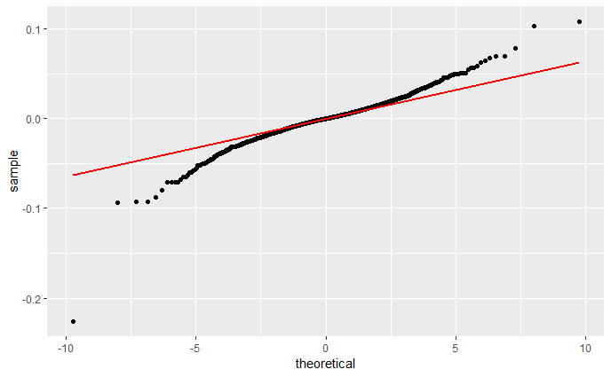

```r
df = as.integer(best.Fit.tGarch@fit$coef["shape"])
resid.tgarch = data.frame(Residuals = best.Fit.tGarch@residuals)
qq.Garch.t <- ggplot(resid.tgarch, aes(sample = Residuals))+
  stat_qq(distribution = stats::qt, dparams = df) +
  stat_qq_line(distribution = stats::qt, dparams = df, size = 0.8, col = "red")
qq.Garch.t
```

### Prediction of log-return with ARIMA(0,0,2)-t-GARCH(1,1)

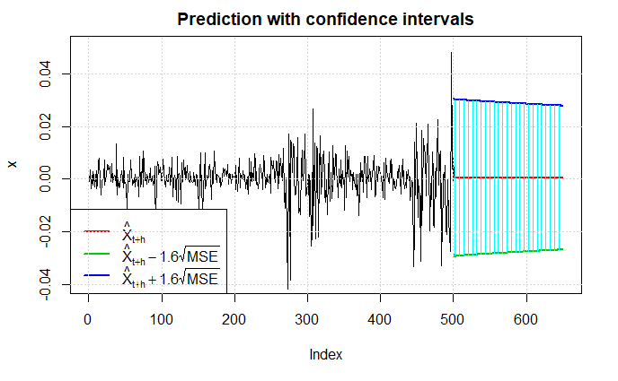

```r
fGarch::predict(best.Fit.tGarch,n.ahead=150,plot=TRUE,conf=.9,nx=500)
```

### References

Ruey, S. Tsay. 2012. “AN Introduction to Analysis of Financial Data with R.” In. JOHN WILEY & SONS, INC.

Shi Chen, Cathy Yi-Hsuan Chen, Wolfgang Karl Härdle, TM Lee, and Bobby Ong. 2016. “A First Econometric Analysis of the Crix Family.” In. Humboldt-Universität zu Berlin. http://sfb649.wiwi.hu-berlin.de/.

“YAHOO Finanzen.” Website. https://finance.yahoo.com/quote/%5EGSPC?p=^GSPC.